# Assignment 11: Predictive Modeling - Part 2

*How to do it?*:

- Open the Rmarkdown file of this assignment (link) in Rstudio.
- Right under each **question**, insert a code chunk (you can use the hotkey `Ctrl + Alt + I` to add a code chunk) and code the solution for the question.
- `Knit` the rmarkdown file (hotkey: `Ctrl + Alt + K`) to export an html.
- Publish the html file to your Githiub Page.

*Submission*: Submit the link on Github of the assignment to Blackboard.

1. Install the package `mlbench` and use the follows to import the data

```r
library(mlbench)
data(PimaIndiansDiabetes)
df <- PimaIndiansDiabetes
```

- Set seed to be 2020.
- The target variable is `diabetes`
- Partition the data into 80% training and 20% testing.

```r
set.seed(2020)
names(df)[9] <- 'target'
library(caret)
splitIndex <- createDataPartition(df$target, p = .80,
                                  list = FALSE)
df_train <- df[ splitIndex,]
df_test <- df[-splitIndex,]
```

2. Tuning Decision Tree: Use cross-validation with 10 k-folds to find the maxdepth with the greatest accuracy. Plot the accuracy associated with different maxdepths against the maxdepths. The range to search for maxdepth is from 1 to 10.

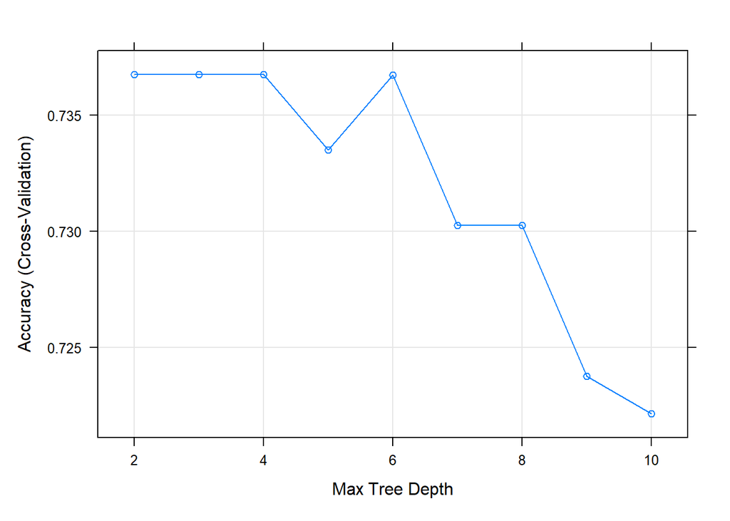

```r
tuneGrid = expand.grid(maxdepth = 2:10)
trControl = trainControl(method = "cv",
                         number = 10)
tree_approach2 <- train(target~., data=df_train,
                                method = "rpart2",
                                trControl = trControl,
                                tuneGrid = tuneGrid)
plot(tree_approach2)
```

```r
print(tree_approach2)
```

```
## CART
##
## 615 samples
##   8 predictor
##   2 classes: 'neg', 'pos'
##
## No pre-processing
## Resampling: Cross-Validated (10 fold)
## Summary of sample sizes: 554, 554, 554, 554, 553, 554, ...
## Resampling results across tuning parameters:
##
##   maxdepth  Accuracy   Kappa
##    2        0.7367530  0.4149078
##    3        0.7367530  0.4149078
##    4        0.7367530  0.4149078
##    5        0.7335008  0.4126352
##    6        0.7367266  0.4210583
##    7        0.7302485  0.4080404
##    8        0.7302485  0.4080404
##    9        0.7237705  0.3891845
##   10        0.7221576  0.3804269
##
## Accuracy was used to select the optimal model using the largest value.
## The final value used for the model was maxdepth = 2.
```

3. Make the final decision to select the maxdepth for your decision tree. Is your selected maxdepth the same as the maxdepth found in 2?

```r
#I would use maxdepth 2 for the decision tree because it provides the highest accuracy with the lowest number of trees. This is the same choice as Caret  in 2.
```

4. Calculate the accuracy of your decision tree (the decision tree with your selected maxdepth in 3) on the test data.

```r
pred <- predict(tree_approach2, df_test)
cm <- confusionMatrix(data = pred, reference = df_test$target, positive = "pos")
cm$overall[1]
```

```
##  Accuracy
## 0.7254902
```